# STA 6709 HW 4

Ken Zhao

This is a spatial polygons dataset of the continental USA containing region and 2010/2015 population data. This is nice for someone who wants to the US sectioned off or want to see population trends by state from 2010 to 2015.

I initialized the package that contains this dataset.

```r
#initialize spData package
library(spData)
```

I converted the data to spatial polygons

```r
#read spatial polygons data for USA
library(sp)
library(sf)
us_states
```

```
## Simple feature collection with 49 features and 6 fields
## Geometry type: MULTIPOLYGON
## Dimension:     XY
## Bounding box:  xmin: -124.7042 ymin: 24.55868 xmax: -66.9824 ymax: 49.38436
## Geodetic CRS:  NAD83
## First 10 features:
##    GEOID        NAME   REGION             AREA total_pop_10 total_pop_15
## 1     01     Alabama    South 133709.27 [km^2]      4712651      4830620
## 2     04     Arizona     West 295281.25 [km^2]      6246816      6641928
## 3     08    Colorado     West 269573.06 [km^2]      4887061      5278906
## 4     09 Connecticut Norteast  12976.59 [km^2]      3545837      3593222
## 5     12     Florida    South 151052.01 [km^2]     18511620     19645772
## 6     13     Georgia    South 152725.21 [km^2]      9468815     10006693
## 7     16       Idaho     West 216512.66 [km^2]      1526797      1616547
## 8     18     Indiana  Midwest  93648.40 [km^2]      6417398      6568645
## 9     20      Kansas  Midwest 213037.08 [km^2]      2809329      2892987
## 10    22   Louisiana    South 122345.76 [km^2]      4429940      4625253
##                          geometry
## 1  MULTIPOLYGON (((-88.20006 3...
## 2  MULTIPOLYGON (((-114.7196 3...
## 3  MULTIPOLYGON (((-109.0501 4...
## 4  MULTIPOLYGON (((-73.48731 4...
## 5  MULTIPOLYGON (((-81.81169 2...
## 6  MULTIPOLYGON (((-85.60516 3...
## 7  MULTIPOLYGON (((-116.916 45...
## 8  MULTIPOLYGON (((-87.52404 4...
## 9  MULTIPOLYGON (((-102.0517 4...
## 10 MULTIPOLYGON (((-92.01783 2...
```

```r
uspolygons=as(us_states,Class = "Spatial")
```

I initialized leaflet and checked the polygons of the US to make sure it’s working

```r
#initiate leaflet
library(leaflet)

#check polygons of USA
uspolygons %>%
  leaflet() %>%
  addPolygons() %>%
  addTiles()
```

[interactive chart not shown]

I manually created categorical colors for the regions in the dataset. I tried to choose them to make them stand out from each other

```r
#create categorical color variable for regions
uspolygons=as(us_states,Class = "Spatial")
regioncolor=c("blue","green","orange","red")
names(regioncolor)=c("Norteast","South","West","Midwest")
uspolygons$color=regioncolor[uspolygons$REGION]
```

Then, I plotted the categorical variable REGION here. Pretty straightforward.

```r
#plot regions by color
uspolygons %>%
  leaflet() %>%
  addProviderTiles("Stamen") %>%
  addPolygons(
    color = ~color,
    label = ~paste0(NAME," ",REGION," ",total_pop_15),
    fillOpacity = .5
  )
```

[interactive chart not shown]

I created numeric colors for US state population in 2010 using ggplot2.

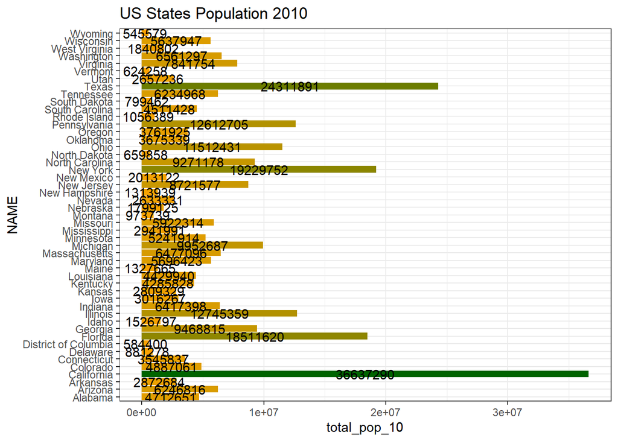

```r
#create numeric colors for USA state population in 2010
uspolygons=as(us_states,Class = "Spatial")
library(ggplot2)
usnumericcolor <- ggplot(uspolygons@data) +
  aes(
    x = NAME,
    y = total_pop_10,
    fill = total_pop_10,
    label = paste0(total_pop_10),
    total_pop_15=total_pop_15
  ) +
  geom_col() +
  geom_text(position = position_stack(0.5)) +
  scale_fill_gradient2(low = "darkred",mid = "orange",high = "darkgreen",midpoint = 50) +
  theme_bw() +
  theme(legend.position = "none") +
  coord_flip() +
  labs(
    title = "US States Population 2010"
  )
usnumericcolor
```

Then, I merged those colors onto my spatial polygons so I could use plot it.

```r
#merge color to spatial polygons dataset
uspolygons@data=merge(
  x=uspolygons@data,
  y=as.data.frame(ggplot_build(usnumericcolor)$data[[1]])[,c("total_pop_15","fill")],
  by="total_pop_15",
  all.x=TRUE,
  all.y=FALSE,
  sort=FALSE)
```

I plotted the colors using leaflet. As we can see, Texas and California dominate population-wise, with many of the eastern states holding down the middle and the rest of the country lagging behind. One might look at this and inform him or herself about the most popular states to live in, if they want to follow the crowd. They could also plan to go against the grain and live in the areas that are more sparse by going towards the middle or northwest of the country.

```r
#plot numeric colors by USA state 2010 population
uspolygons %>%
  leaflet() %>%
  addProviderTiles("Stamen") %>%
  addPolygons(
    color = ~fill,
    label = ~paste0(NAME," ",REGION," ",total_pop_10),
    fillOpacity = .5)
```

[interactive chart not shown]

I did the same process of creating colors for 2015

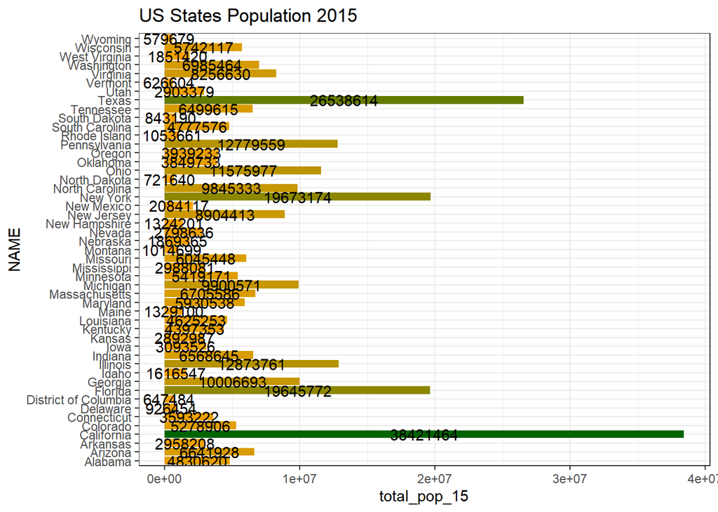

```r
#create numeric colors for USA state population in 2015
uspolygons=as(us_states,Class = "Spatial")
usnumericcolor <- ggplot(uspolygons@data) +
  aes(
    x = NAME,
    y = total_pop_15,
    fill = total_pop_15,
    label = paste0(total_pop_15),
    total_pop_10=total_pop_10
  ) +
  geom_col() +
  geom_text(position = position_stack(0.5)) +
  scale_fill_gradient2(low = "darkred",mid = "orange",high = "darkgreen",midpoint = 50) +
  theme_bw() +
  theme(legend.position = "none") +
  coord_flip() +
  labs(
    title = "US States Population 2015"
  )
usnumericcolor
```

```r
#merge color to spatial polygons dataset
uspolygons@data=merge(
  x=uspolygons@data,
  y=as.data.frame(ggplot_build(usnumericcolor)$data[[1]])[,c("total_pop_10","fill")],
  by="total_pop_10",
  all.x=TRUE,
  all.y=FALSE,
  sort=FALSE)
```

We don’t really see much of a change in 5 years here. We can possibly infer that the US has a fairly stable population ratio among its states, and that the hypothetical person who wants to live somewhere can be assured that their preference of population density is met for a while.

```r
#plot numeric colors by USA state 2015 population
uspolygons %>%
  leaflet() %>%
  addProviderTiles("Stamen") %>%
  addPolygons(
    color = ~fill,
    label = ~paste0(NAME," ",REGION," ",total_pop_15),
    fillOpacity = .5
  )
```

[interactive chart not shown]